# Data extraction tips

Woon Ee Lin

13 January, 2020

Tips to extract data straight from an excel file extracted using ehints.

### Preparation work

Step 1: Enter data into a designated textbox in Edoc. Standardize data entry using “acronym expansion” or a EXCEL template. Ensure that outcome values are within brackets/braces

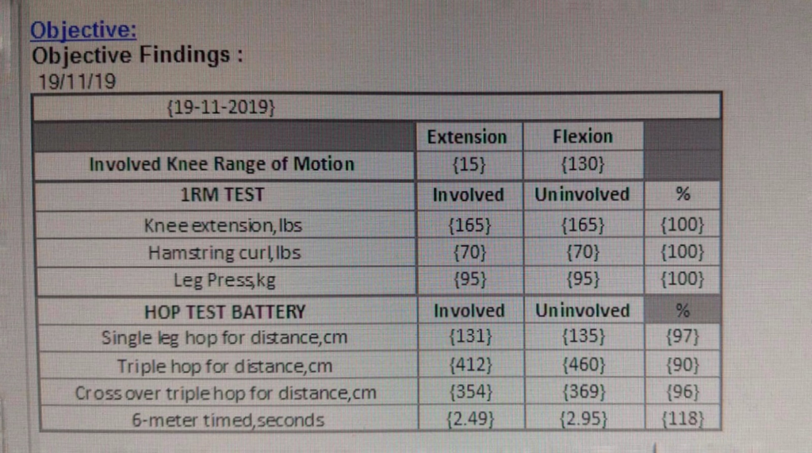

Step 2: Use `EHINTS` to extract and save data as an `EXCEL` or `csv` file

Step 3: Download [`R` software](https://cran.r-project.org/bin/windows/base/) & [`Rstudio`](https://rstudio.com/products/rstudio/download/)

Step 4: Open `RStudio`.

### Start using RStudio

Step 5: Set working directory

[figure not shown]

Step 6: Load/install `R` packages

```r
# load R packages and install them if they are missing
for (i in c("readxl", "stringr", "dplyr")) {
    if (!require(i, character.only = TRUE)) {
        install.packages(i, dependencies = TRUE)
        library(i, character.only = TRUE)
    }
}

# library(stringr); library(dplyr) ## if packages are already installed in R

# if(!require(readxl)){ install.packages('readxl') library(readxl)}
# if(!require(stringr)){ install.packages('stringr') library(stringr)}
# if(!require(dplyr)){ install.packages('dplyr') library(dplyr)}
```

### Data extraction

Step 7: Read the `csv` file  
* Use the `readxl` package to read `EXCEL` files  
* Use the `excel.link` or `XLconnect` packages to read password-protected `EXCEL` files. [Details](https://stackoverflow.com/questions/35852722/how-do-you-read-a-password-protected-excel-file-into-r/43915133)

```r
acl <- read.csv("ACL csv 2.csv")
# acl <- read.csv("C:/Users/SGH/Dropbox/HUATAR ABC/ALPHA/ACL data extraction files/Markdown file/ACL csv 2.csv")
```

Download a copy of the toy dataset

|  | Pt.id | Entered.Date | Item.Left.Label | Value.Text | Entered.Year | Document.Name |
| --- | --- | --- | --- | --- | --- | --- |
| 1 | ACL0000001A | 7/15/2019 | Problems : | 13/3/19 - Right Anterior Cruciate Ligament reconstruction, hamstrings graft on 22/02/19 | 2019 | PT Session Notes |
| 2 | ACL0000001A | 7/30/2019 | Objective Findings : | 1/7/19 - stairs: up - poor quad contraction, right knee dynamic valgus // manually support to facilitate knee control reduce right knee pain 14/5/19 1RM TEST Date Involved Uninvolved % Knee extension … | 2019 | PT Session Notes |
| 3 | ACL0000001A | 7/30/2019 | Problems : | 13/3/19 - Right Anterior Cruciate Ligament reconstruction, hamstrings graft on 22/02/19 | 2019 | PT Session Notes |
| 4 | ACL0000001A | 9/3/2019 | Objective Findings : | 1/7/19 - stairs: up - poor quad contraction, right knee dynamic valgus // manually support to facilitate knee control reduce right knee pain 14/5/19 1RM TEST Date Involved Uninvolved % Knee extension … | 2019 | PT Session Notes |
| 5 | ACL0000001A | 9/3/2019 | Problems : | 13/3/19 - Right Anterior Cruciate Ligament reconstruction, hamstrings graft on 22/02/19 | 2019 | PT Session Notes |
| 6 | ACL0000001A | 9/17/2019 | Objective Findings : | 1/7/19 - stairs: up - poor quad contraction, right knee dynamic valgus // manually support to facilitate knee control reduce right knee pain 14/5/19 1RM TEST Date Involved Uninvolved % Knee extension … | 2019 | PT Session Notes |
| 7 | ACL0000001A | 9/17/2019 | Problems : | 13/3/19 - Right Anterior Cruciate Ligament reconstruction, hamstrings graft on 22/02/19 | 2019 | PT Session Notes |
| 8 | ACL0000001A | 10/1/2019 | Objective Findings : | 1/10/19 (01-10-2019) Extension Flexion ROM (-5) (140) 1RM TEST Involved Uninvolved % Knee extension (lbs) (30) (35) (86) Hamstring curl (lbs) (25) (30) (83) Leg Press (kg) (35) (50) (70) 1/7/19 - stai… | 2019 | PT Session Notes |
| 9 | ACL0000001A | 10/1/2019 | Problems : | 13/3/19 - Right Anterior Cruciate Ligament reconstruction, hamstrings graft on 22/02/19 | 2019 | PT Session Notes |
| 10 | ACL0000002A | 5/15/2019 | Objective Findings : | 15/05/19: left knee range 0-125 degree straight leg raise lag 5 degree 17/04/19: left knee range 0-115 degree straight leg raise lag 10 degree mild swelling and warm 8/4/19 Left knee flexion range 4 -… | 2019 | PT Session Notes |

[output cut: 17 more lines]

Step 8: Make headers lowercase to make life (a little) easier

```r
names(acl) <- tolower(make.names(names(acl), unique=TRUE))
```

Step 9a: Select columns that you are interested in

```r
#pt.id and value.text are headers of columns of interest
acl2 <- dplyr::select(acl, "pt.id", "value.text")
```

Step 9b: Select rows that you are interested in

```r
# str_which() identifies row numbers of cells containing :"Extension Flexion ROM (...)"
row_numbers_with_values <- str_which(acl$value.text, "Extension Flexion ROM\\s\\(")

acl2 <- acl2  %>%
  slice ( row_numbers_with_values )

# acl2 <- slice(acl2, 8,16,24)
# 8,16,24 are row numbers
```

Step 10: Extract everything that is within brackets

```r
# .   # match any character
# *   # zero or more times
# ?   # matching as few characters as possible
outcome1 <- str_extract_all(acl2$value.text, "(?<=\\().*?(?=\\))")
```

```
## [[1]]
##  [1] "01-10-2019" "-5"         "140"        "lbs"        "30"
##  [6] "35"         "86"         "lbs"        "25"         "30"
## [11] "83"         "kg"         "35"         "50"         "70"
## [16] "lbs"        "lbs"        "kg"         "lbs"
##
## [[2]]
##  [1] "04-10-2019" "0"          "140"        "lbs"        "40"
##  [6] "80"         "50"         "lbs"        "20"         "40"
## [11] "50"         "kg"         "35"         "65"         "54"
##
## [[3]]
##  [1] "04-10-2019" "0"          "135"        "lbs"        "40"
##  [6] "60"         "67"         "lbs"        "25"         "25"
## [11] "100"        "kg"         "45"         "50"         "90"
## [16] "lbs"        "lbs"        "kg"         "lbs"        "lbs"
## [21] "kg"         "lbs"        "lbs"        "kg"         "lbs"
## [26] "lbs"        "kg"
```

Step 11: Create table from extracted data

```r
outcome2 <- data.frame(do.call(rbind, outcome1))
```

Step 12: Select columns that are of interest

```r
outcome2 <- dplyr::select(outcome2, X1:X3, X5:X7, X9:X11, X13:X15)
```

|  | X1 | X2 | X3 | X5 | X6 | X7 | X9 | X10 | X11 | X13 | X14 | X15 |
| --- | --- | --- | --- | --- | --- | --- | --- | --- | --- | --- | --- | --- |
| 1 | 01-10-2019 | -5 | 140 | 30 | 35 | 86 | 25 | 30 | 83 | 35 | 50 | 70 |
| 2 | 04-10-2019 | 0 | 140 | 40 | 80 | 50 | 20 | 40 | 50 | 35 | 65 | 54 |
| 3 | 04-10-2019 | 0 | 135 | 40 | 60 | 67 | 25 | 25 | 100 | 45 | 50 | 90 |

Step 13: Extract patient identifiers

```r
ptid <-dplyr::select(acl2,"pt.id")
```

| pt.id |
| --- |
| ACL0000001A |
| ACL0000002A |
| ACL0000003A |

Step 14: Merge 2 tables

```r
ptid_with_outcomes <- dplyr::bind_cols(ptid,outcome2)

# ptid_with_outcomes <- outcome2 %>%
#   mutate(ptid = acl2%>% pull(pt.id)) %>%
#   dplyr::select(ptid, everything())
```

|  | pt.id | X1 | X2 | X3 | X5 | X6 | X7 | X9 | X10 | X11 | X13 | X14 | X15 |
| --- | --- | --- | --- | --- | --- | --- | --- | --- | --- | --- | --- | --- | --- |
| 1 | ACL0000001A | 01-10-2019 | -5 | 140 | 30 | 35 | 86 | 25 | 30 | 83 | 35 | 50 | 70 |
| 2 | ACL0000002A | 04-10-2019 | 0 | 140 | 40 | 80 | 50 | 20 | 40 | 50 | 35 | 65 | 54 |
| 3 | ACL0000003A | 04-10-2019 | 0 | 135 | 40 | 60 | 67 | 25 | 25 | 100 | 45 | 50 | 90 |

Step 15: Rename headers

```r
final <- ptid_with_outcomes %>%
  dplyr::rename(
    ax_date = X1,
    extension_range = X2,
    flexion_range = X3,
    knee_extension_uninvolved = X5,
    knee_extension_involved = X6,
    knee_extension_LSI = X7,
    hamstring_curl_uninvolved = X9,
    hamstring_curl_involved = X10,
    hamstring_curl_LSI = X11,
    leg_press_uninvolved = X13,
    leg_press_involved = X14,
    leg_press_LSI = X15)
```

| pt.id | ax_date | extension_range | flexion_range | knee_extension_uninvolved | knee_extension_involved | knee_extension_LSI | hamstring_curl_uninvolved | hamstring_curl_involved | hamstring_curl_LSI | leg_press_uninvolved | leg_press_involved | leg_press_LSI |
| --- | --- | --- | --- | --- | --- | --- | --- | --- | --- | --- | --- | --- |
| ACL0000001A | 01-10-2019 | -5 | 140 | 30 | 35 | 86 | 25 | 30 | 83 | 35 | 50 | 70 |
| ACL0000002A | 04-10-2019 | 0 | 140 | 40 | 80 | 50 | 20 | 40 | 50 | 35 | 65 | 54 |
| ACL0000003A | 04-10-2019 | 0 | 135 | 40 | 60 | 67 | 25 | 25 | 100 | 45 | 50 | 90 |

### Export extracted data as `csv` file

Final step: Export as a excel file to share it with others 👋

```r
write.csv(final, "the_data_i_painstakingly_extracted_using_r.csv",row.names=FALSE, na="NA")
```

### TL;DR

Just the **`R codes`**, please

```r
# load the libraries and install them if they are missing
for (i in c("readxl", "stringr", "dplyr")) {
  if(! require(i, character.only = TRUE)){
    install.packages(i, dependencies = TRUE)
    library(i, character.only=TRUE)}
}


acl <- read.csv("ACL csv 2.csv")
names(acl) <- tolower(make.names(names(acl), unique=TRUE))
row_numbers_with_values <- str_which(acl$value.text, "Extension Flexion ROM\\s\\(")

acl2 <- acl %>%
  slice ( row_numbers_with_values ) %>%
  dplyr::select(pt.id, value.text)

# .   # match any character
# *   # zero or more times
# ?   # matching as few characters as possible
outcome1 <- str_extract_all(acl2$value.text, "(?<=\\().*?(?=\\))")
outcome1
outcome2 <- data.frame(do.call(rbind, outcome1))
outcome2 <- select(outcome2, X1:X3, X5:X7, X9:X11, X13:X15)


ptid <-select(acl2,"pt.id")
datatable(ptid)
ptid_with_outcomes <- dplyr::bind_cols(ptid,outcome2)
# ptid_with_outcomes <- outcome2 %>%
#   mutate(ptid = acl2%>% pull(pt.id)) %>%
#   dplyr::select(ptid, everything())

final <- ptid_with_outcomes %>%
  dplyr::rename(
    ax_date = X1,
    extension_range = X2,
    flexion_range = X3,
    knee_extension_uninvolved = X5,
    knee_extension_involved = X6,
    knee_extension_LSI = X7,
    hamstring_curl_uninvolved = X9,
    hamstring_curl_involved = X10,
    hamstring_curl_LSI = X11,
    leg_press_uninvolved = X13,
    leg_press_involved = X14,
    leg_press_LSI = X15)


write.csv(final, "the_data_i_painstakingly_extracted_using_r.csv",row.names=FALSE, na="NA")
```

### Queries?

Contact Us

[figure not shown]